# Predicting Customer Churn for Abuja Electricity Distribution Company (AEDC).Update1

## AEDC Abuja Customer Churn Prediction Project

1. Data loading and inspection
2. Data cleaning and missing value handling (median for numeric, mode for categorical)
3. Exploratory Data Analysis (EDA) with visualizations
4. Feature engineering (margin, subscribed power, churn encoding, date extraction)
5. Model training using Logistic Regression and Random Forest
6. Model evaluation using accuracy, confusion matrix, classification report, and ROC-AUC
7. Business recommendations and churn retention strategy development

### 1. IMPORT LIBRARIES

```python
import pandas as pd
import numpy as np

import matplotlib.pyplot as plt
import seaborn as sns

from sklearn.model_selection import train_test_split, StratifiedKFold, GridSearchCV
from sklearn.preprocessing import StandardScaler
from sklearn.metrics import (
    classification_report, confusion_matrix, roc_auc_score, roc_curve
)

from sklearn.linear_model import LogisticRegression
from sklearn.ensemble import RandomForestClassifier

from imblearn.combine import SMOTETomek
from imblearn.over_sampling import SMOTE
from imblearn.pipeline import Pipeline

import warnings
warnings.filterwarnings("ignore")
```

### Load dataset and inspect

```python
df = pd.read_csv('aedc_cx_dataset_2500.csv')
print(f"Shape: {{df.shape}}")
print(f"Columns ({{len(df.columns)}}):", df.columns.tolist())
print("\nFirst 3 rows:")
df.head(3)
```

[output not shown]

|  | Name | Customer_ID | Account_Number | Meter_Number | Age | Location | Income | Purchase_Frequency | Purchase_History | Churn_Status | ... | Service_Charge | Debt_Arrears | Previous_Meter_Reading | Current_Meter_Reading | Energy_Consumption | Billing_Cycle | Billing_Accuracy | Power_Outage_Frequency | Power_Outage_Duration_Hours | Service_Usage |
| --- | --- | --- | --- | --- | --- | --- | --- | --- | --- | --- | --- | --- | --- | --- | --- | --- | --- | --- | --- | --- | --- |
| 0 | Tina Williams | CUST500000 | AEDC100000 | MTR200000 | 46 | Gwagwalada, Abuja, Nigeria | 56391 | 11 | 34149.30 | No | ... | 1374.03 | 95.31 | 5674 | 5709 | 35 | Jun-2025 | 0.97 | 8 | 4.26 | 323.31 |
| 1 | Crystal Hill | CUST500001 | AEDC100001 | MTR200001 | 50 | Apo, Abuja, Nigeria | 47059 | 7 | 14923.63 | No | ... | 1377.09 | 6260.40 | 2438 | 2454 | 16 | Mar-2025 | 0.85 | 4 | 11.23 | 20.00 |
| 2 | Joy Sanchez | CUST500002 | AEDC100002 | MTR200002 | 32 | Maitama, Abuja, Nigeria | 30000 | 9 | 8351.26 | No | ... | 2305.53 | 14660.09 | 2885 | 2898 | 13 | Feb-2025 | 0.81 | 6 | 16.61 | 26.15 |

3 rows × 33 columns

### Data types and statistical summary

```python
print("\nData Types:")
print(df.dtypes)
print("\nNumerical Summary:")
df.describe().round(2)
```

```
Data Types:
Name                              object
Customer_ID                       object
Account_Number                    object
Meter_Number                      object
Age                                int64
Location                          object
Income                             int64
Purchase_Frequency                 int64
Purchase_History                 float64
Churn_Status                      object
Customer_Satisfaction_Score      float64
Average_Resolution_Time_Hours    float64
Complaint_Frequency                int64
Transaction_DateTime              object
Transaction_Reference             object
Receipt_Number                    object
Payment_Type                      object
Meter_Type                        object
Tariff_Class                      object
Amount_Paid                      float64
Units_Purchased                  float64
Token                             object
VAT                              float64
Service_Charge                   float64
Debt_Arrears                     float64
Previous_Meter_Reading             int64
Current_Meter_Reading              int64
Energy_Consumption                 int64
Billing_Cycle                     object
Billing_Accuracy                 float64
Power_Outage_Frequency             int64
Power_Outage_Duration_Hours      float64
Service_Usage                    float64
dtype: object

Numerical Summary:
```

|  | Age | Income | Purchase_Frequency | Purchase_History | Customer_Satisfaction_Score | Average_Resolution_Time_Hours | Complaint_Frequency | Amount_Paid | Units_Purchased | VAT | Service_Charge | Debt_Arrears | Previous_Meter_Reading | Current_Meter_Reading | Energy_Consumption | Billing_Accuracy | Power_Outage_Frequency | Power_Outage_Duration_Hours | Service_Usage |
| --- | --- | --- | --- | --- | --- | --- | --- | --- | --- | --- | --- | --- | --- | --- | --- | --- | --- | --- | --- |
| count | 2500.00 | 2500.00 | 2500.00 | 2500.00 | 2500.00 | 2500.00 | 2500.00 | 2500.00 | 2500.00 | 2500.00 | 2500.00 | 2500.00 | 2500.00 | 2500.00 | 2500.00 | 2500.00 | 2500.00 | 2500.00 | 2500.00 |
| mean | 37.37 | 76404.92 | 7.56 | 52198.01 | 3.86 | 30.51 | 2.16 | 6615.55 | 77.18 | 496.17 | 1385.81 | 20609.21 | 4557.56 | 4634.24 | 76.68 | 0.91 | 4.62 | 8.03 | 577.65 |
| std | 10.68 | 57017.91 | 2.89 | 53770.63 | 0.67 | 11.45 | 2.02 | 6220.55 | 77.26 | 466.54 | 625.07 | 17090.54 | 2015.91 | 2014.53 | 77.26 | 0.06 | 2.80 | 6.23 | 603.67 |
| min | 18.00 | 30000.00 | 1.00 | 1077.01 | 1.27 | 2.00 | 0.00 | 673.53 | 5.49 | 50.51 | 300.01 | 20.69 | 1001.00 | 1016.00 | 5.00 | 0.72 | 0.00 | 0.00 | 20.00 |
| 25% | 30.00 | 36167.75 | 6.00 | 20087.94 | 3.43 | 22.68 | 0.00 | 2871.53 | 31.32 | 215.37 | 843.46 | 8432.13 | 2864.75 | 2947.50 | 31.00 | 0.87 | 3.00 | 3.14 | 204.87 |
| 50% | 37.00 | 59873.50 | 8.00 | 35385.04 | 3.95 | 30.18 | 2.00 | 4682.45 | 54.18 | 351.18 | 1386.05 | 17335.66 | 4515.00 | 4604.00 | 54.00 | 0.91 | 5.00 | 6.75 | 382.29 |
| 75% | 45.00 | 93790.50 | 10.00 | 66867.64 | 4.42 | 38.17 | 4.00 | 8392.91 | 96.82 | 629.47 | 1919.71 | 26508.60 | 6316.50 | 6383.75 | 96.00 | 0.96 | 7.00 | 11.56 | 730.49 |
| max | 65.00 | 671936.00 | 15.00 | 871446.65 | 4.98 | 68.59 | 10.00 | 114160.22 | 1403.34 | 8562.02 | 2499.70 | 79803.38 | 7997.00 | 8382.00 | 1403.00 | 1.00 | 15.00 | 36.14 | 5000.00 |

### Data Cleaning & Missing Value Handling

Token (1,242 missing (49.7%) — purely structural. Postpaid customers do not generate a token string because they pay after consumption, not before. All other 32 columns: 0 missing values. This is a clean dataset, unusually so for utility billing data.

```python
missing = df.isnull().sum()
print("Columns with missing values:")
print('Token', '[1242]')
print(f"\nToken missing: {{1,242}}, rows = {{49.7}}%")
print(f"Postpaid meter count:  {{1,242}}")
```

[output not shown]

```python
df['Token'] = df['Token'].fillna('NO_TOKEN')

# Numeric columns: fill with median (robust to outliers)
for col in df.select_dtypes(include=['float64','int64']).columns:
    if df[col].isnull().any():
        df[col] = df[col].fillna(df[col].median())
        print(f"  Filled {{col}} with median")

# Categorical columns: fill with mode (most frequent value)
for col in df.select_dtypes(include=['object']).columns:
    if df[col].isnull().any():
        df[col] = df[col].fillna(df[col].mode()[0])
        print(f"  Filled {{col}} with mode")

print(f"\nTotal remaining missing values: {{0}}")
```

[output not shown]

#### CONVERT TRANSACTION DATETIME

```python
df["Transaction_DateTime"] = pd.to_datetime(df["Transaction_DateTime"])

df["Year"] = df["Transaction_DateTime"].dt.year
df["Month"] = df["Transaction_DateTime"].dt.month
df["Month_Name"] = df["Transaction_DateTime"].dt.month_name()

df.head()
```

|  | Name | Customer_ID | Account_Number | Meter_Number | Age | Location | Income | Purchase_Frequency | Purchase_History | Churn_Status | ... | Current_Meter_Reading | Energy_Consumption | Billing_Cycle | Billing_Accuracy | Power_Outage_Frequency | Power_Outage_Duration_Hours | Service_Usage | Year | Month | Month_Name |
| --- | --- | --- | --- | --- | --- | --- | --- | --- | --- | --- | --- | --- | --- | --- | --- | --- | --- | --- | --- | --- | --- |
| 0 | Tina Williams | CUST500000 | AEDC100000 | MTR200000 | 46 | Gwagwalada, Abuja, Nigeria | 56391 | 11 | 34149.30 | No | ... | 5709 | 35 | Jun-2025 | 0.97 | 8 | 4.26 | 323.31 | 2025 | 8 | August |
| 1 | Crystal Hill | CUST500001 | AEDC100001 | MTR200001 | 50 | Apo, Abuja, Nigeria | 47059 | 7 | 14923.63 | No | ... | 2454 | 16 | Mar-2025 | 0.85 | 4 | 11.23 | 20.00 | 2026 | 1 | January |
| 2 | Joy Sanchez | CUST500002 | AEDC100002 | MTR200002 | 32 | Maitama, Abuja, Nigeria | 30000 | 9 | 8351.26 | No | ... | 2898 | 13 | Feb-2025 | 0.81 | 6 | 16.61 | 26.15 | 2025 | 5 | May |
| 3 | Chelsea Anderson | CUST500003 | AEDC100003 | MTR200003 | 36 | Gwagwalada, Abuja, Nigeria | 30000 | 12 | 20455.28 | No | ... | 6900 | 19 | Feb-2025 | 0.84 | 5 | 12.96 | 269.80 | 2025 | 11 | November |
| 4 | Christina Serrano | CUST500004 | AEDC100004 | MTR200004 | 42 | Lugbe, Abuja, Nigeria | 72897 | 11 | 26725.03 | No | ... | 4091 | 30 | May-2025 | 0.94 | 5 | 5.12 | 383.67 | 2026 | 3 | March |

5 rows × 36 columns

Now we can analyze:

monthly consumption, yearly trends, forecasting

### 3. EXPLORATORY DATA ANALYSIS (EDA)

#### CHURN DISTRIBUTION

```python
df["Churn_Status"].value_counts()
```

```
Churn_Status
No     1936
Yes     564
Name: count, dtype: int64
```

```python
churn_counts = df['Churn_Status'].value_counts()
churn_pct    = df['Churn_Status'].value_counts(normalize=True) * 100
```

```python
print("Class Distribution:")
print(f"  Retained  (0): {churn_counts[0]:,}  ({churn_pct[0]:.1f}%)")
print(f"  Churned   (1): {churn_counts[1]:,}  ({churn_pct[1]:.1f}%)")
print(f"  Imbalance Ratio: {churn_counts[0]/churn_counts[1]:.1f} : 1")
```

```
Class Distribution:
  Retained  (0): 1,936  (77.4%)
  Churned   (1): 564  (22.6%)
  Imbalance Ratio: 3.4 : 1
```

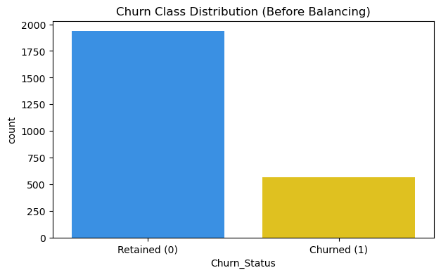

```python
plt.figure(figsize=(7, 4))
sns.countplot(x='Churn_Status', data=df, palette=["#1E90FF", "#FFD700"])
plt.title('Churn Class Distribution (Before Balancing)')
plt.xticks([0, 1], ['Retained (0)', 'Churned (1)'])
plt.show()
```

Class Distribution:

Business Meaning

AEDC has fewer churn customers, but those customers represent huge business risk:

loss of revenue

debt recovery challenges

customer dissatisfaction spreading to others

#### INCOME DISTRIBUTION

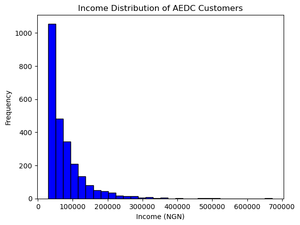

```python
plt.hist(df["Income"], bins=30, color="Blue", edgecolor="black")
plt.title("Income Distribution of AEDC Customers")
plt.xlabel("Income (NGN)")
plt.ylabel("Frequency")
plt.show()
```

Income is right-skewed:

many low/middle-income customers and few high-income customers

#### PURCHASE HISTORY DISTRIBUTION

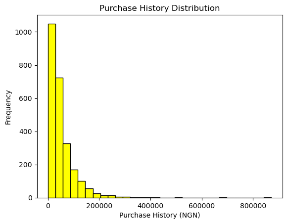

```python
plt.hist(df["Purchase_History"], bins=30, color="Yellow", edgecolor="black")
plt.title("Purchase History Distribution")
plt.xlabel("Purchase History (NGN)")
plt.ylabel("Frequency")
plt.show()
```

High purchase history indicates high-value customers

purchase history depends on income and usage

#### OUTAGE FREQUENCY DISTRIBUTION

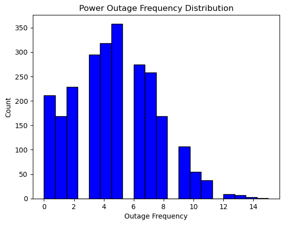

```python
plt.hist(df["Power_Outage_Frequency"], bins=20, color="Blue", edgecolor="black")
plt.title("Power Outage Frequency Distribution")
plt.xlabel("Outage Frequency")
plt.ylabel("Count")
plt.show()
```

#### OUTAGE DURATION DISTRIBUTION

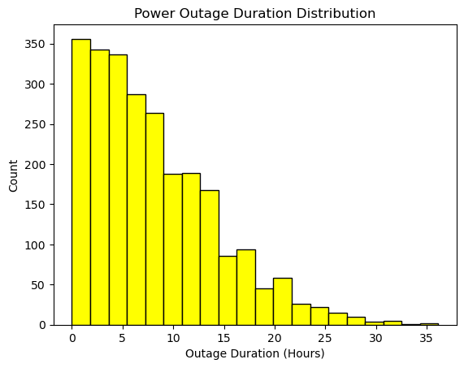

```python
plt.hist(df["Power_Outage_Duration_Hours"], bins=20, color="YELLOW", edgecolor="black")
plt.title("Power Outage Duration Distribution")
plt.xlabel("Outage Duration (Hours)")
plt.ylabel("Count")
plt.show()
```

#### SERVICE USAGE DISTRIBUTION

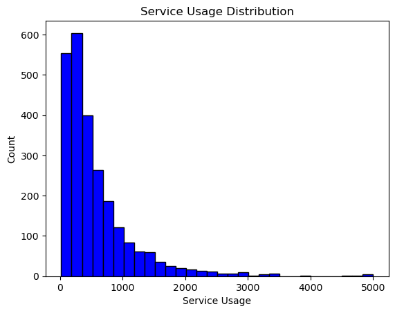

```python
plt.hist(df["Service_Usage"], bins=30, color="BLUE", edgecolor="black")
plt.title("Service Usage Distribution")
plt.xlabel("Service Usage")
plt.ylabel("Count")
plt.show()
```

higher service usage = higher electricity demand

high usage customers are valuable and should be retained

#### SATISFACTION SCORE DISTRIBUTION

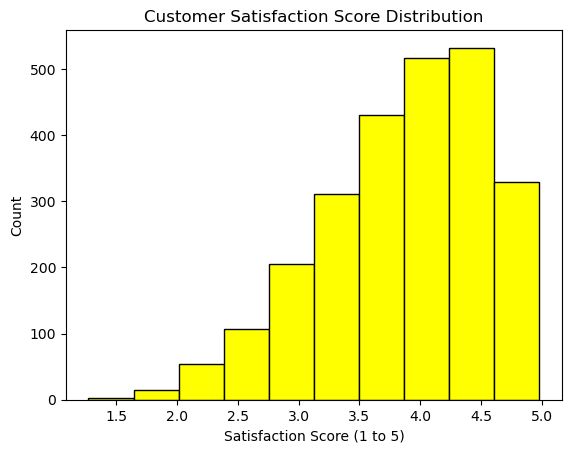

```python
plt.hist(df["Customer_Satisfaction_Score"], bins=10, color="YELLOW", edgecolor="black")
plt.title("Customer Satisfaction Score Distribution")
plt.xlabel("Satisfaction Score (1 to 5)")
plt.ylabel("Count")
plt.show()
```

Scores closer to 5 mean satisfied customers

scores closer to 1 indicate dissatisfaction and churn risk

#### COMPLAINT FREQUENCY DISTRIBUTION

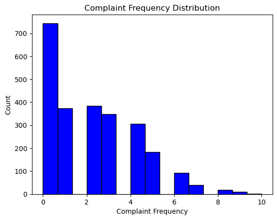

```python
plt.hist(df["Complaint_Frequency"], bins=15, color="BLUE", edgecolor="black")
plt.title("Complaint Frequency Distribution")
plt.xlabel("Complaint Frequency")
plt.ylabel("Count")
plt.show()
```

Customers with frequent complaints are likely unhappy and may churn.

#### RESOLUTION TIME DISTRIBUTION

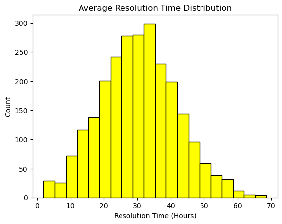

```python
plt.hist(df["Average_Resolution_Time_Hours"], bins=20, color="YELLOW", edgecolor="black")
plt.title("Average Resolution Time Distribution")
plt.xlabel("Resolution Time (Hours)")
plt.ylabel("Count")
plt.show()
```

Longer resolution time suggests poor customer support and affects satisfaction.

### CHURN VS KEY FEATURES

#### CHURN VS INCOME

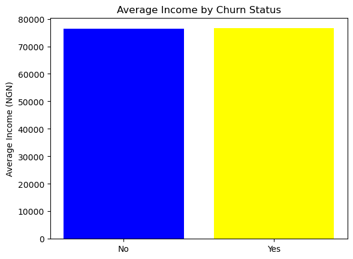

```
Churn_Status
No     76353.816632
Yes    76580.347518
Name: Income, dtype: float64
```

```python
income_churn = df.groupby("Churn_Status")["Income"].mean()

plt.bar(income_churn.index, income_churn.values, color=["BLUE", "YELLOW"])
plt.title("Average Income by Churn Status")
plt.ylabel("Average Income (NGN)")
plt.show()

income_churn
```

If churned customers earn less:

affordability and payment difficulty drives churn.

#### CHURN VS PURCHASE HISTORY

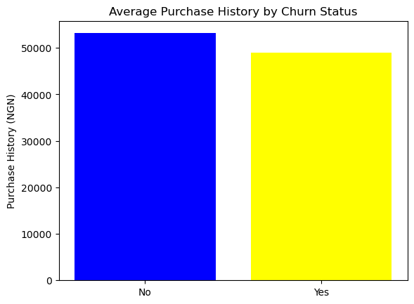

```
Churn_Status
No     53150.952965
Yes    48926.921968
Name: Purchase_History, dtype: float64
```

```python
purchase_churn = df.groupby("Churn_Status")["Purchase_History"].mean()

plt.bar(purchase_churn.index, purchase_churn.values, color=["BLUE", "YELLOW"])
plt.title("Average Purchase History by Churn Status")
plt.ylabel("Purchase History (NGN)")
plt.show()

purchase_churn
```

Low purchase history customers tend to churn because they are less engaged.

#### CHURN VS OUTAGE FREQUENCY

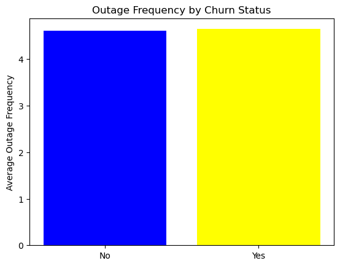

```
Churn_Status
No     4.613120
Yes    4.647163
Name: Power_Outage_Frequency, dtype: float64
```

```python
outage_churn = df.groupby("Churn_Status")["Power_Outage_Frequency"].mean()

plt.bar(outage_churn.index, outage_churn.values, color=["BLUE", "YELLOW"])
plt.title("Outage Frequency by Churn Status")
plt.ylabel("Average Outage Frequency")
plt.show()

outage_churn
```

If churn customers experience higher outages, reliability is a churn driver.

### ENERGY CONSUMPTION ANALYSIS (MONTHLY & YEARLY)

#### CONSUMPTION DISTRIBUTION

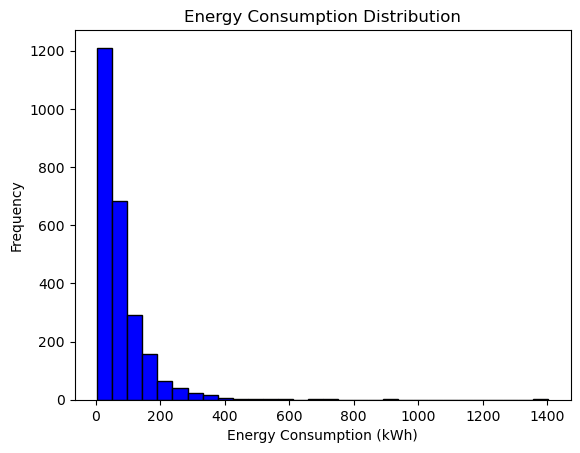

```python
plt.hist(df["Energy_Consumption"], bins=30, color="BLUE", edgecolor="black")
plt.title("Energy Consumption Distribution")
plt.xlabel("Energy Consumption (kWh)")
plt.ylabel("Frequency")
plt.show()
```

Shows:

typical household usage

high usage customers (commercial)

#### MONTHLY CONSUMPTION TREND

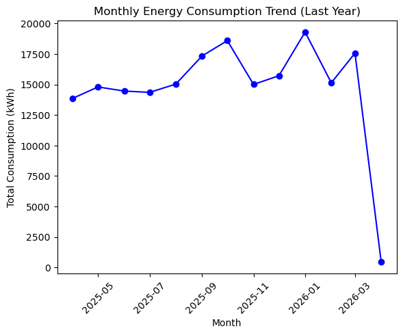

|  | Year | Month | Energy_Consumption | Date |
| --- | --- | --- | --- | --- |
| 0 | 2025 | 4 | 13868 | 2025-04-01 |
| 1 | 2025 | 5 | 14803 | 2025-05-01 |
| 2 | 2025 | 6 | 14468 | 2025-06-01 |
| 3 | 2025 | 7 | 14358 | 2025-07-01 |
| 4 | 2025 | 8 | 15036 | 2025-08-01 |
| 5 | 2025 | 9 | 17338 | 2025-09-01 |
| 6 | 2025 | 10 | 18603 | 2025-10-01 |
| 7 | 2025 | 11 | 15011 | 2025-11-01 |
| 8 | 2025 | 12 | 15721 | 2025-12-01 |
| 9 | 2026 | 1 | 19303 | 2026-01-01 |
| 10 | 2026 | 2 | 15144 | 2026-02-01 |
| 11 | 2026 | 3 | 17580 | 2026-03-01 |
| 12 | 2026 | 4 | 465 | 2026-04-01 |

```python
monthly_consumption = df.groupby(["Year","Month"])["Energy_Consumption"].sum().reset_index()

monthly_consumption["Date"] = pd.to_datetime(
    monthly_consumption["Year"].astype(str) + "-" + monthly_consumption["Month"].astype(str)
)

plt.plot(monthly_consumption["Date"], monthly_consumption["Energy_Consumption"], color="BLUE", marker="o")
plt.title("Monthly Energy Consumption Trend (Last Year)")
plt.xlabel("Month")
plt.ylabel("Total Consumption (kWh)")
plt.xticks(rotation=45)
plt.show()

monthly_consumption
```

Shows consumption demand variation across the year.

### FORECASTING CONSUMPTION

#### MOVING AVERAGE FORECAST (3 MONTHS)

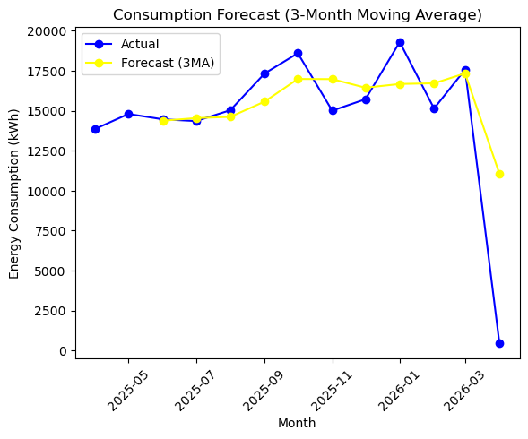

```python
monthly_consumption["Forecast_3MA"] = monthly_consumption["Energy_Consumption"].rolling(3).mean()

plt.plot(monthly_consumption["Date"], monthly_consumption["Energy_Consumption"], color="BLUE", marker="o", label="Actual")
plt.plot(monthly_consumption["Date"], monthly_consumption["Forecast_3MA"], color="YELLOW", marker="o", label="Forecast (3MA)")

plt.title("Consumption Forecast (3-Month Moving Average)")
plt.xlabel("Month")
plt.ylabel("Energy Consumption (kWh)")
plt.legend()
plt.xticks(rotation=45)
plt.show()
```

The forecast line smoothens fluctuations and predicts expected future consumption.

### MARGIN ANALYSIS

#### CALCULATE MARGINS

Assume cost per kWh = ₦225

```python
df["Estimated_Cost"] = df["Units_Purchased"] * 225
df["Margin"] = df["Amount_Paid"] - df["Estimated_Cost"]

df[["Amount_Paid","Units_Purchased","Estimated_Cost","Margin"]].head()
```

|  | Amount_Paid | Units_Purchased | Estimated_Cost | Margin |
| --- | --- | --- | --- | --- |
| 0 | 3614.02 | 35.84 | 8064.00 | -4449.98 |
| 1 | 1994.74 | 16.67 | 3750.75 | -1756.01 |
| 2 | 1060.22 | 13.72 | 3087.00 | -2026.78 |
| 3 | 1526.15 | 19.27 | 4335.75 | -2809.60 |
| 4 | 2506.17 | 30.37 | 6833.25 | -4327.08 |

Interpretation

Margin > 0 = profit customer

Margin < 0 = loss customer

#### MARGIN DISTRIBUTION

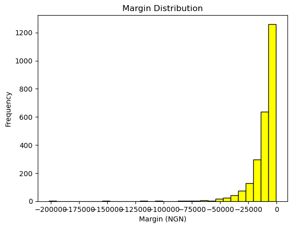

```python
plt.hist(df["Margin"], bins=30, color="YELLOW", edgecolor="black")
plt.title("Margin Distribution")
plt.xlabel("Margin (NGN)")
plt.ylabel("Frequency")
plt.show()
```

Helps AEDC identify profitability distribution.

### SUBSCRIBED POWER ESTIMATION

#### CREATE SUBSCRIBED POWER FEATURE

```python
df["Subscribed_Power_kVA"] = np.where(df["Service_Usage"] > 2000, 15,
                             np.where(df["Service_Usage"] > 1200, 10,
                             np.where(df["Service_Usage"] > 700, 5, 2)))

df["Subscribed_Power_kVA"].value_counts()
```

```
Subscribed_Power_kVA
2     1841
5      384
10     188
15      87
Name: count, dtype: int64
```

#### SUBSCRIBED POWER VISUALIZATION

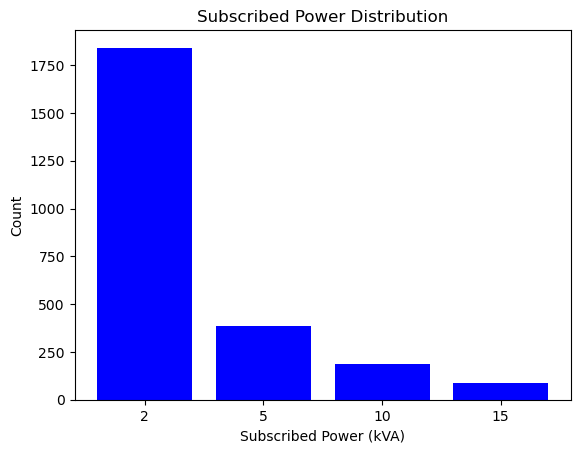

```python
sub_counts = df["Subscribed_Power_kVA"].value_counts()

plt.bar(sub_counts.index.astype(str), sub_counts.values, color="BLUE")
plt.title("Subscribed Power Distribution")
plt.xlabel("Subscribed Power (kVA)")
plt.ylabel("Count")
plt.show()
```

Shows customer segmentation:

2kVA = small household

15kVA = business/high-value

#### CORRELATION HEATMAP

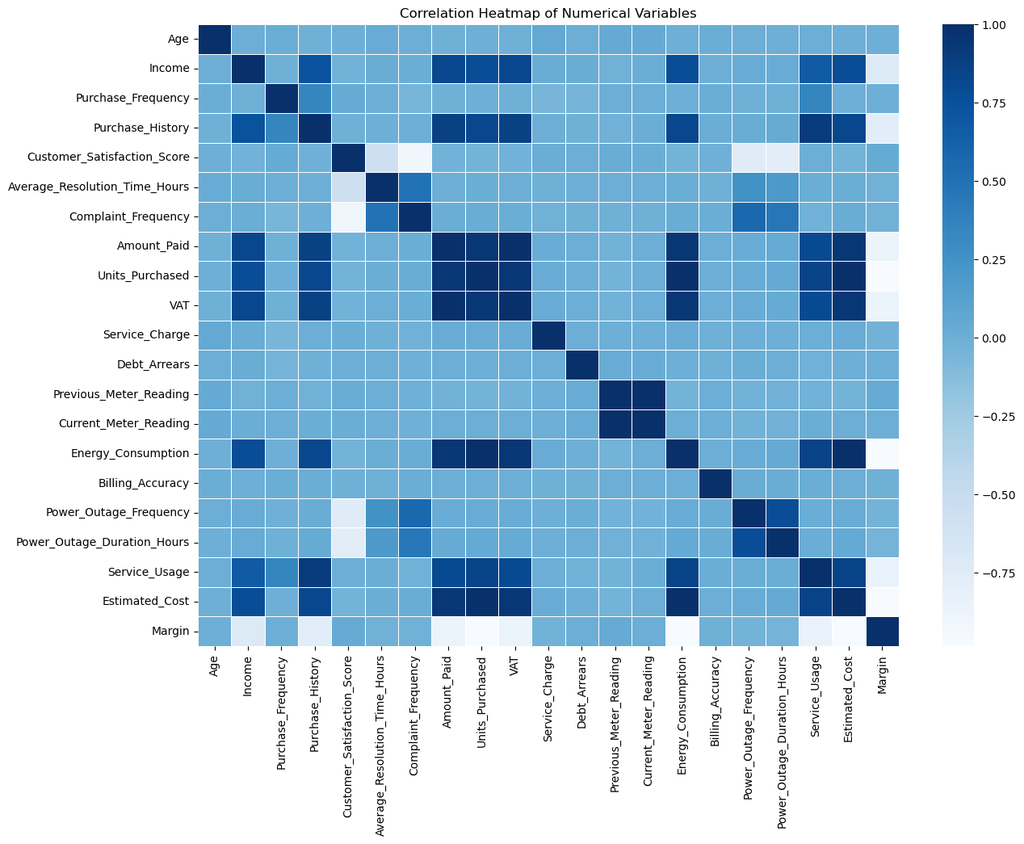

```python
plt.figure(figsize=(14,10))
corr = df.select_dtypes(include=["int64","float64"]).corr()

sns.heatmap(corr, cmap="Blues", linewidths=0.5)
plt.title("Correlation Heatmap of Numerical Variables")
plt.show()
```

Strong correlations:

Income ↔ Purchase History

Satisfaction ↔ Complaints (negative)